# Group Assignment: Replicating Ouss and Stevenson (2023)

Group Members: Julian Schmidt, Laurens Mauz, Isa Afridi, Lukas Simon

2026-01-20

## 1.1 Differences-in-Differences

Difference-in-Differences is a causal inference method used on observed data (i.e. not experimental setting) to estimate causal effects. It does so by comparing the changes in outcomes over time between a population that is enrolled in a program (the Treatment Group) and a population that is not (the Control Group). The intuition is the following: We want to know what would have happened to the treated units had they not been treated. Since we cannot observe this counterfactual, we use the trend of the control group as a proxy for what the treated group’s trend would have been.

### Identification

$$\begin{aligned}
\mathbb{E}[Y_2 \mid W = 1] - \mathbb{E}[Y_1 \mid W = 1]
&\stackrel{\text{consistency}}{=} \mathbb{E}[Y_2(1) \mid W = 1] -
\mathbb{E}[Y_1(1) \mid W = 1] \\
&= \mathbb{E}[Y_2(1) - Y_1(1) \mid W = 1] +
\color{blue}{\mathbb{E}[Y_2(0) - Y_2(0) \mid W = 1]} +
\color{blue}{\mathbb{E}[Y_1(0) - Y_1(0) \mid W = 1]} \\
&= \underbrace{\mathbb{E}[Y_2(1) - Y_2(0) \mid W = 1]}_{\tau_{ATT}}
+ \underbrace{\mathbb{E}[Y_2(0) - Y_1(0) \mid W =
1]}_{\text{counterfactual time trend}} - \underbrace{\mathbb{E}[Y_1(1) -
Y_1(0) \mid W = 1]}_{\text{anticipation effect}}
\end{aligned}$$

Unlike standard Cross-Sectional OLS, which relies on the unconfoundedness assumption ($Y(0), Y(1) \perp W \mid X$), DiD relaxes this requirement. It allows for selection bias—where individuals choose treatment based on unobserved characteristics—provided that these unobserved factors are time-invariant, and the parallel trends and no-anticipation effect assumptions hold.

The former requires trends in the absence of treatment to be parallel, i.e. $\mathbb{E}[Y_2(0) - Y_1(0) \mid W=1]=\mathbb{E}[Y_2(0) - Y_1(0) \mid W=0]$.

The no-anticipation effect assumption requires that the outcomes of the treatment group are only affected by the treatment after the treatment is given, i.e.,
$$\mathbb{E}[Y_1(1)
- Y_1(0) \mid W=1] = 0$$
.

The downside of not needing the unconfoundedness assumption is that we can only identify the ATT, not the ATU or ATE. This is the case because we do not assume parallel trends under treatment, i.e., $\mathbb{E}[Y_2(1) - Y_1(1) \mid W=1]=\mathbb{E}[Y_2(1) - Y_1(1) \mid W=0]$. In other words, the control group might be different in some unobserved confounders which make treatment effects heterogeneous from the treatment group.

In practice researchers often rely on conditional parallel trends. This assumption acknowledges that treatment and control groups may have different compositions (e.g., age or gender distributions) that naturally lead to diverging trends. Therefore trends are parallel only after adjusting for these covariates. Furthermore, with repeated cross-sectional data researcher control for relevant covariates in order to account for potential group-composition shifts between periods.

## 1.2 Custom Double ML DiD Function

## 1.3a Replication of Ouss and Stevenson (2023)

### 1.3a.2 Descriptives

#### Cash Bail System

The paper “Does Cash Bail Deter Misconduct?” (Ouss and Stevenson, 2023) investigates how cash bails affect the likelihood of a defendant violating the bail conditions. Cash bailout refers to a financial collateral the defendant must pay to remain out of jail while they await their trial. If the defendant fulfils the bail conditions they get their collateral back. The conditions which need to be fulfilled in order for the defendant to get the cash bail back after the court trials are over:

- **Appearing to all hearings**
- **Not committing another crime**

If an individual violates either of these conditions, they lose the bail collateral. Furthermore, if an individual does not even pay the collateral in the beginning, they are detained in jail until the court trials are over.

The cash bail system thus is supposed to ensure individuals appear for the hearings and don’t commit further crimes through a monetary incentive. Thus individuals who do not pay the bail collateral are jailed, because the lack of monetary incentive would make it more likely for them to violate the conditions.

#### Policy Reform

The reform analysed in this paper is a change in the policy of Philadelphia’s public prosecutors, who in February 2018 recommended to no longer require cash-bail for many low-level offenses. The motivation of this and similar reforms in other jurisdictions is to protect economically vulnerable, often minority groups which cannot afford to post cash-bail. If the cash-bail system is successful in motivating individuals to not violate the bail conditions, then releasing defendants without financial incentive should lead to more violations. This paper thus uses DiD to investigate whether eligible defenders (i.e. defenders eligible for the new bail policy, who committed low-level crimes) who now no longer need to post bail are after the reform more likely to miss court hearings and commit further crimes.

Importantly, the reform entailed the Philadelphia prosecutor only recommending this change in bail policy instead of simply deciding, because the decision whether and how much cash-bail is required is made by bail magistrates, who have the ultimate discretion here. While this discretion with magistrates makes it thus imaginable that this reform did not actually change anything, figure 1 shows that the share of defendants released without cash-bail (the correct legal term being Release on own Recognizance, or ROR) increased significantly, by around 15-20 percentage points. In the replication section, we will test this increase in ROR also through a DiD design. We can thus confirm that the reform had significant measure effects, which the authors argue were not result of a change in formal rules, but rather of a change in norms.

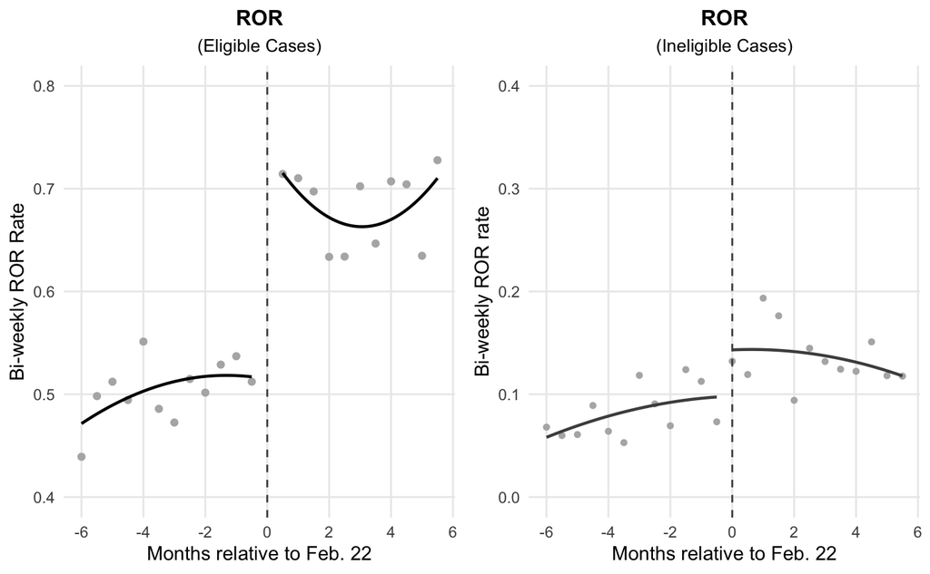

*Figure 1a: ROR Time Trend for eligible (left) and ineligible right) cases*

#### Target Parameters and Controls

The authors scraped the data for this analysis off the Philadelphia court websites. The auxiliary target parameters are:

- **Release on Recognizance (ROR):** Whether a defendant is released without monetary bail or supervisory conditions. As explained in the prior section, measuring ROR is necessary to confirm that the policy actually changed bail-setting behavior.
- **Pretrial Detention:** Defined as spending at least three nights in jail immediately following the initial bail hearing. The DiD will later show that the amount of individuals detained before trial was not affected by the reform. This will be used to argue that any reform affects on the FTA and recidivism variables must be due to the monetary incentive channel and not the detainment channel.

The target parameters of the main DiD analysis are:

- **Failure to Appear (FTA):** Defined as equal to one if the defendant fails to appear for at least one court date associated with the case.
- **Recidivism:** Defined as equal to one if the defendant is charged with a new offense within six months of the bail hearing.

Both of these main target parameters make up the conditions which cannot be violated if the defendant wants to keep their bail money.

To account for case and defendant characteristics, the authors include the following controls in the DiD analyses:

- **Defendant Demographics:** Race, gender, and age at arrest.
- **Criminal History:** The presence and number of prior FTAs and prior convictions (limited to a nine-year window before the bail hearing),,.
- **Case Characteristics:** The type of offense (aggregated to the 23 most common offenses plus a catchall category), the grade of offense, and whether the defendant was represented by a public defender.
- **Procedural Factors:** The specific bail magistrate overseeing the hearing, the day of the week, and the magistrate work shift.
- **Standard errors:** in these analyses are clustered at the offense level to account for correlations within offense types.

### 1.3a.3 Replication Results

#### DiD TWFE

$$(1) \quad Y_{i} = \alpha + \beta Post_{i} + \delta Post_{i} \times
Eligible_{i} + \lambda Eligible_{i} + \theta \mathbf{X}_{i} +
\epsilon_{i}.$$

| Characteristic | ROR | Jail | FTA | Recidivism |
| --- | --- | --- | --- | --- |
|  | ROR | Jail3days | hasfta | Rec6mo |
| Eligible x Post 02/21 | 0.1328*** (0.0242) | -0.0123 (0.0237) | -0.0076 (0.0197) | -0.0268 (0.0159) |
| Mean dep. var. | 0.5050 | 0.1690 | 0.2470 | 0.1710 |
| Fixed-Effects: | ------------------ | ---------------- | ---------------- | ---------------- |
| off | Yes | Yes | Yes | Yes |
| yq | Yes | Yes | Yes | Yes |
| _____________________ | __________________ | ________________ | ________________ | ________________ |
| S.E.: Clustered | by: off | by: off | by: off | by: off |
| Observations | 22,589 | 22,589 | 22,589 | 22,589 |

*Table 1*: DiD Estimates of ROR, Jail, FTA, and Recidivism

We will not interpret these TWFE DiD results by themselves here, but rather use them to benchmark our Double ML result in the following section.

#### DiD Double ML

We observe $(Y_i, D_i, T_i, X_i)$ where $D_i \in \{0,1\}$ is the treatment variable and $T_i \in \{0,1\}$ is the time variable. ATT is identified in repeated cross sectional DiD under parallel trend and standard overlap assumption.

For the Double ML estimation we use the same dataset with the same target parameters and covariates as in the TWFE implementation.
Here now a brief explanation of how we constructed the custom Double ML function: We observe $(Y_i, D_i, T_i, X_i)$ where $D_i \in \{0,1\}$ is the treatment variable and $T_i \in \{0,1\}$ is the time variable. The parameter of interest is the ATT (average treatment effect on the treated):
$$\theta_0 = E[(Y(1)_{i} - Y(0)_{i}| D=1, \, T=1
]$$
identified in Cross Sectional DiD under parallel trend and standard overlap assumption.

We use a doubly robust pooled cross section score to get the parameter estimate $\hat{\theta}$ as well as the influence function $\hat{\psi}(\theta)$. To get the score we need to estimate the nuisance parameters:
$$m_0(X) = P(D=1|X)$$
as well as the outcome regressions for each cell $(d,t)$ which is

$$g_{dt,0}(X) = E[Y|D=d,
T=t,X]$$

with the given nuisance parameter function. Since the given function does not allow to conditioning on $(D,T,X)$ we constructed a workaround such that we can get $\hat{g}_{11}(X),\hat{g}_{01}(X), \hat{g}_{10}(X), \hat{g}_{00}(X)$. We estimate that by turning $(D,T)$ into a 4-category variable `DT_combined <- 2 * D + Tt`. We used random forests stacked with lasso to estimate the CEF’s for the outcome and random forests stacked with logit for the propensity score.

We then constructed $\psi_a$ and $\psi_b$ based on the score provided by the [DoubleML](https://docs.doubleml.org/stable/guide/scores.html#id4) documentation. Using this we identify $\theta$ by solving the linear moment equation:

$$E[\psi_a \theta_{0} + \psi_b] = 0 \Rightarrow \theta_{0} = -
\frac{E_i[\psi_b]}{E_i[\psi_a]}$$
To get estimates of $\theta$, we replaced the population averages with sample means. Afterward we constructed the influence function

$$IF_i = \frac{-1}{E[\psi_a]} \cdot
\psi_i(\hat{\theta})$$

To estimate is, we also replaced the population averages with sample means. We then used the estimated values for the influence function to get standard error for our ATT estimator. To recover clustered variance, we used

$$\hat{var}(\hat{\theta}) = \frac{1}{n}\sum_{k=1}^{C} \left(\sum_{i \in
G_{k}} IF_{i}\right)^{2}$$

where C is the number of clusters and $G_{k}$ is the k-th cluster.

The jail estimate of +3% has the opposite sign and is larger in absolute term than estimated through TWFE. Indeed a positive effect of the reform on the number of jailed individuals is surprising, as the reform would intuitively be expected to reduce the number of defendants jailed.

The FTA and recidivism estimates both indicate a decrease of around 3%, which is stronger than estimated by TWFE. The authors propose that these positive effects could stem from the cash-bail having a very negative effect on financially vulnerable groups. For these groups having to pay hundreds or thousands of dollars in bail implies additional hardship and stress, which could decrease the likelihood of the defendant appearing at court and increase the chances of the defendants committing further crimes.

DiD ATT Results

| Outcome | ATT | P-Value | Lower_CI | Upper_CI |
| --- | --- | --- | --- | --- |
| ROR | 0.091 | 0.015 | 0.017 | 0.165 |
| Jail3days | 0.031 | 0.089 | −0.005 | 0.067 |
| hasfta | −0.033 | 0.062 | −0.067 | 0.002 |
| Rec6mo | −0.028 | 0.032 | −0.053 | −0.002 |

*Table 2: ATT estimates*

#### Heterogeneity

Furthermore we conducted a heterogeneity analysis. Let $D_i \in \{0,1\}$ denote treatment status, $T_i \in \{0,1\}$ a time indicator, and $G_i \in \mathcal G$ a discrete group variable. We are interested in the group-specific average treatment effect on the treated
$$\tau_g \;=\; \mathbb E\!\left[ Y_i(1) - Y_i(0) \mid D_i=1, \, T_i=1, \,
G_i=g \right].$$
The overall ATT is identified by the orthogonal moment condition
$$\mathbb{E}[\psi_{a,i}\theta + \psi_{b,i}] = 0,$$
which yields
$$\theta^{ATT} = -\frac{\mathbb{E}[\psi_b]}{\mathbb{E}[\psi_a]}.$$

To allow for treatment effect heterogeneity, we extend this moment condition to a group-specific version by reweighting with the group indicator $I_{g,i} = \mathbf{1}\{G_i = g\}$:
$$\mathbb{E}\big[I_{g,i}(\psi_{a,i}\tau_g + \psi_{b,i})\big] = 0.$$

Solving the group-specific moment condition gives
$$\tau_g = -\frac{\mathbb{E}[I_g \psi_b]}{\mathbb{E}[I_g \psi_a]},$$
which defines the group average treatment effect on the treated (GATT) implied by the same orthogonal score used to identify the overall ATT.

DiD GATT Results for hasfta

| Group | GATT | P-Value | Lower_CI | Upper_CI |
| --- | --- | --- | --- | --- |
| black | −0.025 | 0.168 | −0.061 | 0.011 |
| white | −0.069 | 0.059 | −0.142 | 0.003 |
| hispanic | 0.000 | 0.985 | −0.043 | 0.044 |

*Table 3: GATT estimates for failure to appear*

DiD GATT Results for Rec6mo

| Group | GATT | P-Value | Lower_CI | Upper_CI |
| --- | --- | --- | --- | --- |
| black | −0.018 | 0.036 | −0.034 | −0.001 |
| white | −0.071 | 0.069 | −0.147 | 0.005 |
| hispanic | 0.008 | 0.790 | −0.053 | 0.070 |

*Table 4: GATT estimates for recindivism*

DiD GATT Results for ROR

| Group | GATT | P-Value | Lower_CI | Upper_CI |
| --- | --- | --- | --- | --- |
| black | 0.098 | 0.025 | 0.012 | 0.183 |
| white | 0.067 | 0.023 | 0.009 | 0.124 |
| hispanic | 0.111 | 0.016 | 0.021 | 0.202 |

*Table 5: GATT estimates for shared of defendants released without bail (ROR)*

DiD GATT Results for Jail3days

| Group | GATT | P-Value | Lower_CI | Upper_CI |
| --- | --- | --- | --- | --- |
| black | −0.007 | 0.782 | −0.058 | 0.044 |
| white | 0.090 | 0.066 | −0.006 | 0.185 |
| hispanic | 0.041 | 0.225 | −0.025 | 0.107 |

*Table 6: GATT estimates for share of defendants jailed*

### 1.3.4 Reflection on DiD Assumptions

#### Policy Context

The district attorney, who would pass the no-cash bail reform in February 2018, was elected to office in November 2017, and before his election success already promised that he would implement the no cash-bail reform. Importantly, the exact timing and extent of the reforms was unknown before February 2018. This implies that significant anticipation effects in the month before the reform are unlikely.

The parallel trends assumption on the other hand would be violated if there were other reforms happening concurrently in Philadelphia. In that case even being able to show that prior to the reform trends were parallel would not be enough. The authors explain that there was only one other judicial reform around that time. On February 15, the DA’s office announced a change in charging practices for marijuana possession, retail theft, and sex work. These cases are therefore removed from the analysis, which should alleviate the problem.

#### Event Study DiD

After considering the policy context and removing cases that were affected by the parallel reform, we run an event-study version of the DiD to confirm that the no-anticipation and parallel trends assumption are fulfilled at least in the past. The authors do this by running a TWFE with monthly lags and leads, as shown in equation (2). We implement the event study using Double ML.

$$(2) Y_{it} = \alpha_{t} + \beta Eligible_{i} + \sum_{t \neq -1}
\delta_{t} Eligible_{i} + \theta \mathbf{X}_{i} + \epsilon_{i}.$$

If the no-anticipation and parallel trends hold then being eligible should only make a difference for the post-treatment months.

```
  -6   -5   -4   -3   -2   -1    0    1    2    3    4 <NA>
1347 2208 2202 2060 1751 1950 1941 2082 1907 2131 2166  578
```

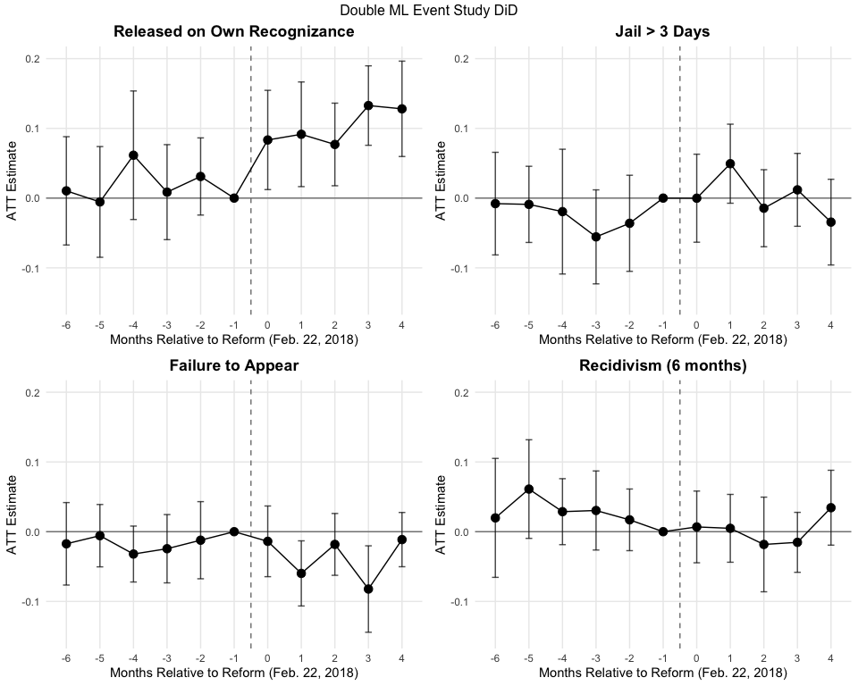

[output not shown]

Concerning the parallel trends assumption the plots show mixed evidence. Only for the RoR outcome it is clearly recognizable that the post-treatment DiD coefficients are clearly more different from zero than the lagged months before the treatment. Especially for the recidivism trends do not seem parallel. In the 5 months before the reform the eligible group experienced a decline in recidivism relative to the trend in the control group.

#### Endogenous Responses

A major threat to this specific study is that legal actors might “game the system”. For example: Police might change who they arrest for “eligible” vs. “ineligible” crimes, or prosecutors might “upcharge” a defendant (assigning a more serious lead charge) to make them ineligible for the No-Cash-Bail policy. This would undermine the identification result of the DiD method, because the groups we compare in the pre- and post period are no longer the same. Controlling for some covariates as we already do wouldn’t solve this problem, as an endogenous change in arrest or charging patterns likely depends on important unobserved covariates like the manner in which the defendant presents themselves during the bail hearing.

The authors test for such a potential change in the legal actors’ responses to the reform by running DiDs with different target parameters, namely the share of defendants whose case the prosecutor completely dropped (Percent of declined), the share whose case they upcharged and the share whose case they downcharged. Furthermore they ran a regression on the weekly number of arrests and cases to test whether the absolute number of defendant changed post-reform. We would have replicated the DiD analyses with Double ML, but unfortunately the required data was not published by the authors. Therefore we will interpret Table 2 from the original paper, which in this report is Table 7.

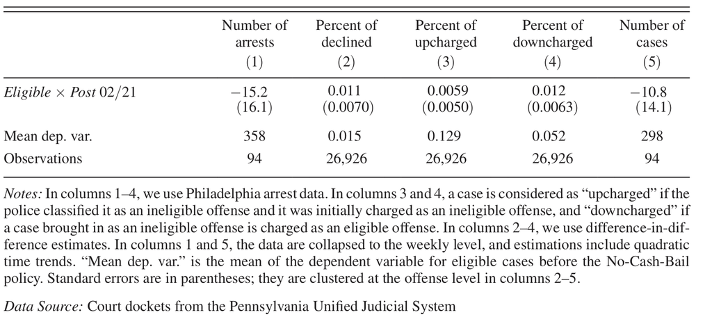

*Table 7: Testing for endogenous responses of the legal actors, taken from Ouss and Stevenson (2023)*

Indeed the results show that the different number of arrests and cases as well as the share of declined, up- and downcharged was not influenced by the reform. This confirms that there was no endogenous response from legal actors. Thus the integrity of our DiD identification is maintained.

#### Channels of Cash-Bail Reform Effects on Violations

There are two channels imaginable through which the reform could increase the likelihood of eligible defendants violating their bail conditions.

1. **Detainment channel:** individuals who before didn’t pay the bail and were jailed had a zero chance of violating (since in jail), while these same individuals now are released and thus have a positive likelihood of misconduct
2. **Financial incentive channel:** individuals who paid bail before the reform and were released are now released without bail, and this missing monetary incentive increases likelihood of violating

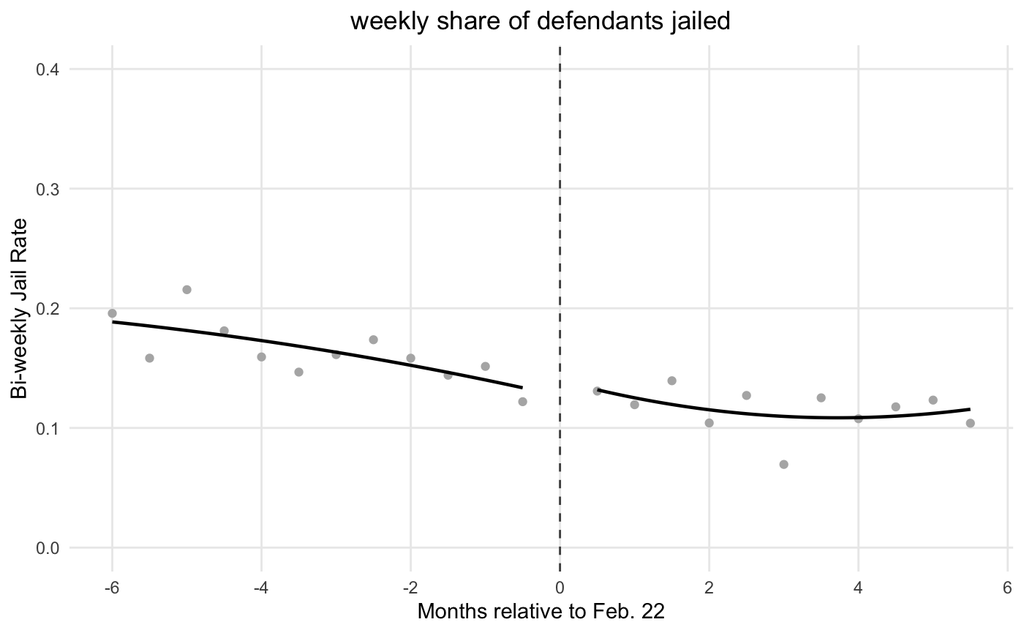

*Figure 2: Share of defendants jailed over time*

The authors argue that in the reform analyzed here, the detainment channel effectively falls away, allowing us to isolate the Financial incentive channel. This is because, despite the share of defendants being released without cash bail increasing by 15-20% percentage points, the share of defendants jailed before and after the reform hasn’t changed, as we shown in the Double ML DiD results in Table 2, as well as above in Figure 2. They argue that this stems from the fact that the same individuals who prior to the reform would have paid the bail to be released are now released without bail, and individuals who would have been jailed then because they didn’t pay bail are now still jailed.

However, while the reform did not affect the number of defendants detained, it might have affected the composition. It is theoretically possible that the “more likely to violate” individuals were released while “less likely to violate” individuals were detained, or the other way around. If this composition swap happened, our DiD design would capture a mix of the detainment effect and monetary incentive effect, which would change the interpretation of the results which the authors propose. A tentative test for this is checking whether the covariate composition of the released versus detained has changed after the reform. We implement this in a TWFE DiD in order to control for parallel trends in composition change between detained and released.

DiD Test for Compositional Shifts

| Characteristic | Interaction (Post × Released) | Std. Error | P-Value | Status |
| --- | --- | --- | --- | --- |
| defendantageatarrest | 0.475 | 0.569 | 0.404 | Stable |
| male | −0.004 | 0.018 | 0.836 | Stable |
| defendantisblack | 0.053 | 0.025 | 0.031 | Shift Detected |
| prior_FTA | 0.027 | 0.019 | 0.148 | Stable |
| prior_9y | 0.011 | 0.024 | 0.654 | Stable |
| past_fel | −0.016 | 0.024 | 0.506 | Stable |
| felony | −0.052 | 0.023 | 0.023 | Shift Detected |

*Table 8: DiD test for covariate composition changes in released and jailed defendants*

Among released defendants, the share which is black increased by 5.3 percentage points more than it did among detained defendants when comparing pre- vs post-reform periods. Similarly, the share of defendants with felony charges decreased by 5.2 percentage points more among released defendants. This suggests that indeed a composition switch took place.

It seems intuitive that more black defendants were released, since more black defendants are economically vulnerable and would have been detained before the reform is unable to pay even a low bail. Explaining the increase in severe offenders being jailed is more difficult. It is surprising that the reform led to stricter detention for some groups, given the policy was explicitly about leniency.

The authors interpret their DiD results strictly in terms of monetary incentive effects. The compositional shifts we showed here serve as a warning that simply ignoring the detainment channel is risky. A further test which could provide more insight into the channels is to estimate the effect of the reform using a DiD design, but subsetting the sample to all released individuals. This, however, can only successfully isolate the monetary incentive channel if we observe all covariats which influence violations, which is likely not the case.

### 1.3.5 Feedback

Difficulties of applying Double ML Both due to our prior familiarity with OLS and the inherently higher complexity Double ML, implementing the estimation process with Double ML was more difficult and required more theoretical rigour. One example of a challenge we had was correctly implementing clustered errors required with our custom Double ML function. Another example is the GATT estimation which was non-trivial. This is because for the subgroup analysis we could not rely on simple conditioning or pseudo-outcome regressions without violating the moment condition that identifies the DiD ATT.

Difficulties of DiD As with any other causal inference method the most challenging is ensuring that the identifying assumption hold. In our case the event study analysis revealed that trends only seem partially parallel, even after conditioning on covariates. Furthermore, the primary goal of this research was to understand the isolated effect of no more cash-bail on defendants. It is likely, however, that also the legal actors involved changed their overall behaviour (endogenous responses) thus also affecting outcomes. Strictly speaking this is not a violation of the DiD assumptions but rather a valid channel through which the reform affects outcomes. Nonetheless this mixture of different effect channels makes it hard to derive policy learning from the results.

Difficulties with Nuisance Parameter package Sometimes the NP package sometimes gave cryptic error messages that were hard to interpret, which seemed to stem from functionalities the package imports. For us also XGBoost still didn’t work after new github update, but we also switched to random forest relatively fast, so this might have been on us not trying enough. Lastly, it might be nice for users who want to implement DiD, if the Nuisance Parameter package had an option to estimates E(Y|D=d, T=t, X) directly without a work around.